# Untitled

Eric Hirsch

11/14/2021

```r
# Load libraries
library(data.table)
library(tidymodels)
library(vip)
library(tidyverse)
library(lmtest)
library(skimr)
library(mltools)
library(psych)
home_sales <- read.csv("D:\\RStudio\\605_Final\\Final\\housing\\train.csv", stringsAsFactors=TRUE, header = TRUE)
home_kaggle_test <- read.csv("D:\\RStudio\\605_Final\\Final\\housing\\test.csv", stringsAsFactors=TRUE, header = TRUE)
home_submit <- read.csv("D:\\RStudio\\605_Final\\Final\\housing\\sample_submission.csv", header = TRUE)
```

#### 1a. Descriptive and Inferential Statistics. Provide univariate descriptive statistics and appropriate plots for the training data set.

```r
dim(home_sales)
```

```
## [1] 1460   81
```

```r
summary(home_sales)
```

```
##        Id           MSSubClass       MSZoning     LotFrontage
##  Min.   :   1.0   Min.   : 20.0   C (all):  10   Min.   : 21.00
##  1st Qu.: 365.8   1st Qu.: 20.0   FV     :  65   1st Qu.: 59.00
##  Median : 730.5   Median : 50.0   RH     :  16   Median : 69.00
##  Mean   : 730.5   Mean   : 56.9   RL     :1151   Mean   : 70.05
##  3rd Qu.:1095.2   3rd Qu.: 70.0   RM     : 218   3rd Qu.: 80.00
##  Max.   :1460.0   Max.   :190.0                  Max.   :313.00
##                                                  NA's   :259
##     LotArea        Street      Alley      LotShape  LandContour  Utilities
##  Min.   :  1300   Grvl:   6   Grvl:  50   IR1:484   Bnk:  63    AllPub:1459
##  1st Qu.:  7554   Pave:1454   Pave:  41   IR2: 41   HLS:  50    NoSeWa:   1
##  Median :  9478               NA's:1369   IR3: 10   Low:  36
##  Mean   : 10517                           Reg:925   Lvl:1311
##  3rd Qu.: 11602
##  Max.   :215245
##
##    LotConfig    LandSlope   Neighborhood   Condition1     Condition2
##  Corner : 263   Gtl:1382   NAmes  :225   Norm   :1260   Norm   :1445
##  CulDSac:  94   Mod:  65   CollgCr:150   Feedr  :  81   Feedr  :   6
##  FR2    :  47   Sev:  13   OldTown:113   Artery :  48   Artery :   2
##  FR3    :   4              Edwards:100   RRAn   :  26   PosN   :   2
##  Inside :1052              Somerst: 86   PosN   :  19   RRNn   :   2
##                            Gilbert: 79   RRAe   :  11   PosA   :   1
##                            (Other):707   (Other):  15   (Other):   2
##    BldgType      HouseStyle   OverallQual      OverallCond      YearBuilt
##  1Fam  :1220   1Story :726   Min.   : 1.000   Min.   :1.000   Min.   :1872
##  2fmCon:  31   2Story :445   1st Qu.: 5.000   1st Qu.:5.000   1st Qu.:1954
##  Duplex:  52   1.5Fin :154   Median : 6.000   Median :5.000   Median :1973
##  Twnhs :  43   SLvl   : 65   Mean   : 6.099   Mean   :5.575   Mean   :1971
##  TwnhsE: 114   SFoyer : 37   3rd Qu.: 7.000   3rd Qu.:6.000   3rd Qu.:2000
##                1.5Unf : 14   Max.   :10.000   Max.   :9.000   Max.   :2010
##                (Other): 19
##   YearRemodAdd    RoofStyle       RoofMatl     Exterior1st   Exterior2nd
##  Min.   :1950   Flat   :  13   CompShg:1434   VinylSd:515   VinylSd:504
##  1st Qu.:1967   Gable  :1141   Tar&Grv:  11   HdBoard:222   MetalSd:214
##  Median :1994   Gambrel:  11   WdShngl:   6   MetalSd:220   HdBoard:207
##  Mean   :1985   Hip    : 286   WdShake:   5   Wd Sdng:206   Wd Sdng:197
##  3rd Qu.:2004   Mansard:   7   ClyTile:   1   Plywood:108   Plywood:142
##  Max.   :2010   Shed   :   2   Membran:   1   CemntBd: 61   CmentBd: 60
##                                (Other):   2   (Other):128   (Other):136
```

[output cut: 81 more lines]

```
##  Min.   :    0.00   Min.   : 1.000   Min.   :2006   WD     :1267
##  1st Qu.:    0.00   1st Qu.: 5.000   1st Qu.:2007   New    : 122
##  Median :    0.00   Median : 6.000   Median :2008   COD    :  43
##  Mean   :   43.49   Mean   : 6.322   Mean   :2008   ConLD  :   9
##  3rd Qu.:    0.00   3rd Qu.: 8.000   3rd Qu.:2009   ConLI  :   5
##  Max.   :15500.00   Max.   :12.000   Max.   :2010   ConLw  :   5
##                                                     (Other):   9
##  SaleCondition    SalePrice
##  Abnorml: 101   Min.   : 34900
##  AdjLand:   4   1st Qu.:129975
##  Alloca :  12   Median :163000
##  Family :  20   Mean   :180921
##  Normal :1198   3rd Qu.:214000
##  Partial: 125   Max.   :755000
##
```

```r
skim(home_sales)
```

Data summary

| Name | home_sales |
| --- | --- |
| Number of rows | 1460 |
| Number of columns | 81 |
| _______________________ |  |
| Column type frequency: |  |
| factor | 43 |
| numeric | 38 |
| ________________________ |  |
| Group variables | None |

**Variable type: factor**

| skim_variable | n_missing | complete_rate | ordered | n_unique | top_counts |
| --- | --- | --- | --- | --- | --- |
| MSZoning | 0 | 1.00 | FALSE | 5 | RL: 1151, RM: 218, FV: 65, RH: 16 |
| Street | 0 | 1.00 | FALSE | 2 | Pav: 1454, Grv: 6 |
| Alley | 1369 | 0.06 | FALSE | 2 | Grv: 50, Pav: 41 |
| LotShape | 0 | 1.00 | FALSE | 4 | Reg: 925, IR1: 484, IR2: 41, IR3: 10 |
| LandContour | 0 | 1.00 | FALSE | 4 | Lvl: 1311, Bnk: 63, HLS: 50, Low: 36 |
| Utilities | 0 | 1.00 | FALSE | 2 | All: 1459, NoS: 1 |
| LotConfig | 0 | 1.00 | FALSE | 5 | Ins: 1052, Cor: 263, Cul: 94, FR2: 47 |
| LandSlope | 0 | 1.00 | FALSE | 3 | Gtl: 1382, Mod: 65, Sev: 13 |
| Neighborhood | 0 | 1.00 | FALSE | 25 | NAm: 225, Col: 150, Old: 113, Edw: 100 |
| Condition1 | 0 | 1.00 | FALSE | 9 | Nor: 1260, Fee: 81, Art: 48, RRA: 26 |
| Condition2 | 0 | 1.00 | FALSE | 8 | Nor: 1445, Fee: 6, Art: 2, Pos: 2 |
| BldgType | 0 | 1.00 | FALSE | 5 | 1Fa: 1220, Twn: 114, Dup: 52, Twn: 43 |
| HouseStyle | 0 | 1.00 | FALSE | 8 | 1St: 726, 2St: 445, 1.5: 154, SLv: 65 |
| RoofStyle | 0 | 1.00 | FALSE | 6 | Gab: 1141, Hip: 286, Fla: 13, Gam: 11 |
| RoofMatl | 0 | 1.00 | FALSE | 8 | Com: 1434, Tar: 11, WdS: 6, WdS: 5 |
| Exterior1st | 0 | 1.00 | FALSE | 15 | Vin: 515, HdB: 222, Met: 220, Wd : 206 |
| Exterior2nd | 0 | 1.00 | FALSE | 16 | Vin: 504, Met: 214, HdB: 207, Wd : 197 |
| MasVnrType | 8 | 0.99 | FALSE | 4 | Non: 864, Brk: 445, Sto: 128, Brk: 15 |
| ExterQual | 0 | 1.00 | FALSE | 4 | TA: 906, Gd: 488, Ex: 52, Fa: 14 |
| ExterCond | 0 | 1.00 | FALSE | 5 | TA: 1282, Gd: 146, Fa: 28, Ex: 3 |
| Foundation | 0 | 1.00 | FALSE | 6 | PCo: 647, CBl: 634, Brk: 146, Sla: 24 |
| BsmtQual | 37 | 0.97 | FALSE | 4 | TA: 649, Gd: 618, Ex: 121, Fa: 35 |
| BsmtCond | 37 | 0.97 | FALSE | 4 | TA: 1311, Gd: 65, Fa: 45, Po: 2 |
| BsmtExposure | 38 | 0.97 | FALSE | 4 | No: 953, Av: 221, Gd: 134, Mn: 114 |
| BsmtFinType1 | 37 | 0.97 | FALSE | 6 | Unf: 430, GLQ: 418, ALQ: 220, BLQ: 148 |
| BsmtFinType2 | 38 | 0.97 | FALSE | 6 | Unf: 1256, Rec: 54, LwQ: 46, BLQ: 33 |
| Heating | 0 | 1.00 | FALSE | 6 | Gas: 1428, Gas: 18, Gra: 7, Wal: 4 |
| HeatingQC | 0 | 1.00 | FALSE | 5 | Ex: 741, TA: 428, Gd: 241, Fa: 49 |
| CentralAir | 0 | 1.00 | FALSE | 2 | Y: 1365, N: 95 |
| Electrical | 1 | 1.00 | FALSE | 5 | SBr: 1334, Fus: 94, Fus: 27, Fus: 3 |
| KitchenQual | 0 | 1.00 | FALSE | 4 | TA: 735, Gd: 586, Ex: 100, Fa: 39 |
| Functional | 0 | 1.00 | FALSE | 7 | Typ: 1360, Min: 34, Min: 31, Mod: 15 |
| FireplaceQu | 690 | 0.53 | FALSE | 5 | Gd: 380, TA: 313, Fa: 33, Ex: 24 |
| GarageType | 81 | 0.94 | FALSE | 6 | Att: 870, Det: 387, Bui: 88, Bas: 19 |
| GarageFinish | 81 | 0.94 | FALSE | 3 | Unf: 605, RFn: 422, Fin: 352 |
| GarageQual | 81 | 0.94 | FALSE | 5 | TA: 1311, Fa: 48, Gd: 14, Ex: 3 |
| GarageCond | 81 | 0.94 | FALSE | 5 | TA: 1326, Fa: 35, Gd: 9, Po: 7 |
| PavedDrive | 0 | 1.00 | FALSE | 3 | Y: 1340, N: 90, P: 30 |
| PoolQC | 1453 | 0.00 | FALSE | 3 | Gd: 3, Ex: 2, Fa: 2 |
| Fence | 1179 | 0.19 | FALSE | 4 | MnP: 157, GdP: 59, GdW: 54, MnW: 11 |
| MiscFeature | 1406 | 0.04 | FALSE | 4 | She: 49, Gar: 2, Oth: 2, Ten: 1 |
| SaleType | 0 | 1.00 | FALSE | 9 | WD: 1267, New: 122, COD: 43, Con: 9 |
| SaleCondition | 0 | 1.00 | FALSE | 6 | Nor: 1198, Par: 125, Abn: 101, Fam: 20 |

**Variable type: numeric**

| skim_variable | n_missing | complete_rate | mean | sd | p0 | p25 | p50 | p75 | p100 | hist |
| --- | --- | --- | --- | --- | --- | --- | --- | --- | --- | --- |
| Id | 0 | 1.00 | 730.50 | 421.61 | 1 | 365.75 | 730.5 | 1095.25 | 1460 | ▇▇▇▇▇ |
| MSSubClass | 0 | 1.00 | 56.90 | 42.30 | 20 | 20.00 | 50.0 | 70.00 | 190 | ▇▅▂▁▁ |
| LotFrontage | 259 | 0.82 | 70.05 | 24.28 | 21 | 59.00 | 69.0 | 80.00 | 313 | ▇▃▁▁▁ |
| LotArea | 0 | 1.00 | 10516.83 | 9981.26 | 1300 | 7553.50 | 9478.5 | 11601.50 | 215245 | ▇▁▁▁▁ |
| OverallQual | 0 | 1.00 | 6.10 | 1.38 | 1 | 5.00 | 6.0 | 7.00 | 10 | ▁▂▇▅▁ |
| OverallCond | 0 | 1.00 | 5.58 | 1.11 | 1 | 5.00 | 5.0 | 6.00 | 9 | ▁▁▇▅▁ |
| YearBuilt | 0 | 1.00 | 1971.27 | 30.20 | 1872 | 1954.00 | 1973.0 | 2000.00 | 2010 | ▁▂▃▆▇ |
| YearRemodAdd | 0 | 1.00 | 1984.87 | 20.65 | 1950 | 1967.00 | 1994.0 | 2004.00 | 2010 | ▅▂▂▃▇ |
| MasVnrArea | 8 | 0.99 | 103.69 | 181.07 | 0 | 0.00 | 0.0 | 166.00 | 1600 | ▇▁▁▁▁ |
| BsmtFinSF1 | 0 | 1.00 | 443.64 | 456.10 | 0 | 0.00 | 383.5 | 712.25 | 5644 | ▇▁▁▁▁ |
| BsmtFinSF2 | 0 | 1.00 | 46.55 | 161.32 | 0 | 0.00 | 0.0 | 0.00 | 1474 | ▇▁▁▁▁ |
| BsmtUnfSF | 0 | 1.00 | 567.24 | 441.87 | 0 | 223.00 | 477.5 | 808.00 | 2336 | ▇▅▂▁▁ |
| TotalBsmtSF | 0 | 1.00 | 1057.43 | 438.71 | 0 | 795.75 | 991.5 | 1298.25 | 6110 | ▇▃▁▁▁ |
| X1stFlrSF | 0 | 1.00 | 1162.63 | 386.59 | 334 | 882.00 | 1087.0 | 1391.25 | 4692 | ▇▅▁▁▁ |
| X2ndFlrSF | 0 | 1.00 | 346.99 | 436.53 | 0 | 0.00 | 0.0 | 728.00 | 2065 | ▇▃▂▁▁ |
| LowQualFinSF | 0 | 1.00 | 5.84 | 48.62 | 0 | 0.00 | 0.0 | 0.00 | 572 | ▇▁▁▁▁ |
| GrLivArea | 0 | 1.00 | 1515.46 | 525.48 | 334 | 1129.50 | 1464.0 | 1776.75 | 5642 | ▇▇▁▁▁ |
| BsmtFullBath | 0 | 1.00 | 0.43 | 0.52 | 0 | 0.00 | 0.0 | 1.00 | 3 | ▇▆▁▁▁ |
| BsmtHalfBath | 0 | 1.00 | 0.06 | 0.24 | 0 | 0.00 | 0.0 | 0.00 | 2 | ▇▁▁▁▁ |
| FullBath | 0 | 1.00 | 1.57 | 0.55 | 0 | 1.00 | 2.0 | 2.00 | 3 | ▁▇▁▇▁ |
| HalfBath | 0 | 1.00 | 0.38 | 0.50 | 0 | 0.00 | 0.0 | 1.00 | 2 | ▇▁▅▁▁ |
| BedroomAbvGr | 0 | 1.00 | 2.87 | 0.82 | 0 | 2.00 | 3.0 | 3.00 | 8 | ▁▇▂▁▁ |
| KitchenAbvGr | 0 | 1.00 | 1.05 | 0.22 | 0 | 1.00 | 1.0 | 1.00 | 3 | ▁▇▁▁▁ |
| TotRmsAbvGrd | 0 | 1.00 | 6.52 | 1.63 | 2 | 5.00 | 6.0 | 7.00 | 14 | ▂▇▇▁▁ |
| Fireplaces | 0 | 1.00 | 0.61 | 0.64 | 0 | 0.00 | 1.0 | 1.00 | 3 | ▇▇▁▁▁ |
| GarageYrBlt | 81 | 0.94 | 1978.51 | 24.69 | 1900 | 1961.00 | 1980.0 | 2002.00 | 2010 | ▁▁▅▅▇ |
| GarageCars | 0 | 1.00 | 1.77 | 0.75 | 0 | 1.00 | 2.0 | 2.00 | 4 | ▁▃▇▂▁ |
| GarageArea | 0 | 1.00 | 472.98 | 213.80 | 0 | 334.50 | 480.0 | 576.00 | 1418 | ▂▇▃▁▁ |
| WoodDeckSF | 0 | 1.00 | 94.24 | 125.34 | 0 | 0.00 | 0.0 | 168.00 | 857 | ▇▂▁▁▁ |
| OpenPorchSF | 0 | 1.00 | 46.66 | 66.26 | 0 | 0.00 | 25.0 | 68.00 | 547 | ▇▁▁▁▁ |
| EnclosedPorch | 0 | 1.00 | 21.95 | 61.12 | 0 | 0.00 | 0.0 | 0.00 | 552 | ▇▁▁▁▁ |
| X3SsnPorch | 0 | 1.00 | 3.41 | 29.32 | 0 | 0.00 | 0.0 | 0.00 | 508 | ▇▁▁▁▁ |
| ScreenPorch | 0 | 1.00 | 15.06 | 55.76 | 0 | 0.00 | 0.0 | 0.00 | 480 | ▇▁▁▁▁ |
| PoolArea | 0 | 1.00 | 2.76 | 40.18 | 0 | 0.00 | 0.0 | 0.00 | 738 | ▇▁▁▁▁ |
| MiscVal | 0 | 1.00 | 43.49 | 496.12 | 0 | 0.00 | 0.0 | 0.00 | 15500 | ▇▁▁▁▁ |
| MoSold | 0 | 1.00 | 6.32 | 2.70 | 1 | 5.00 | 6.0 | 8.00 | 12 | ▃▆▇▃▃ |
| YrSold | 0 | 1.00 | 2007.82 | 1.33 | 2006 | 2007.00 | 2008.0 | 2009.00 | 2010 | ▇▇▇▇▅ |
| SalePrice | 0 | 1.00 | 180921.20 | 79442.50 | 34900 | 129975.00 | 163000.0 | 214000.00 | 755000 | ▇▅▁▁▁ |

```r
str(home_sales)
```

```
## 'data.frame':    1460 obs. of  81 variables:
##  $ Id           : int  1 2 3 4 5 6 7 8 9 10 ...
##  $ MSSubClass   : int  60 20 60 70 60 50 20 60 50 190 ...
##  $ MSZoning     : Factor w/ 5 levels "C (all)","FV",..: 4 4 4 4 4 4 4 4 5 4 ...
##  $ LotFrontage  : int  65 80 68 60 84 85 75 NA 51 50 ...
##  $ LotArea      : int  8450 9600 11250 9550 14260 14115 10084 10382 6120 7420 ...
##  $ Street       : Factor w/ 2 levels "Grvl","Pave": 2 2 2 2 2 2 2 2 2 2 ...
##  $ Alley        : Factor w/ 2 levels "Grvl","Pave": NA NA NA NA NA NA NA NA NA NA ...
##  $ LotShape     : Factor w/ 4 levels "IR1","IR2","IR3",..: 4 4 1 1 1 1 4 1 4 4 ...
##  $ LandContour  : Factor w/ 4 levels "Bnk","HLS","Low",..: 4 4 4 4 4 4 4 4 4 4 ...
##  $ Utilities    : Factor w/ 2 levels "AllPub","NoSeWa": 1 1 1 1 1 1 1 1 1 1 ...
##  $ LotConfig    : Factor w/ 5 levels "Corner","CulDSac",..: 5 3 5 1 3 5 5 1 5 1 ...
##  $ LandSlope    : Factor w/ 3 levels "Gtl","Mod","Sev": 1 1 1 1 1 1 1 1 1 1 ...
##  $ Neighborhood : Factor w/ 25 levels "Blmngtn","Blueste",..: 6 25 6 7 14 12 21 17 18 4 ...
##  $ Condition1   : Factor w/ 9 levels "Artery","Feedr",..: 3 2 3 3 3 3 3 5 1 1 ...
```

[output cut: 67 more lines]

Allthough we could do plots on all of the variables, here we will just focus on those numeric variables most correlated with the dependent variable.

```r
library(tibble)
home_sales_num <- home_sales %>% select_if(is.numeric)
dfCorr <- as.data.frame(cor(home_sales_num, home_sales_num$SalePrice)) %>%
  tibble::rownames_to_column("Variables") %>%
  arrange(desc(abs(V1)))

head(dfCorr, 10)
```

```
##       Variables        V1
## 1     SalePrice 1.0000000
## 2   OverallQual 0.7909816
## 3     GrLivArea 0.7086245
## 4    GarageCars 0.6404092
## 5    GarageArea 0.6234314
## 6   TotalBsmtSF 0.6135806
## 7     X1stFlrSF 0.6058522
## 8      FullBath 0.5606638
## 9  TotRmsAbvGrd 0.5337232
## 10    YearBuilt 0.5228973
```

```r
dfSelectedCols <- home_sales %>%
  dplyr::select(SalePrice, OverallQual, GrLivArea, GarageCars, GarageArea, TotalBsmtSF, X1stFlrSF, FullBath, TotRmsAbvGrd, YearBuilt)

library(ResourceSelection)
```

```
## ResourceSelection 0.3-5   2019-07-22
```

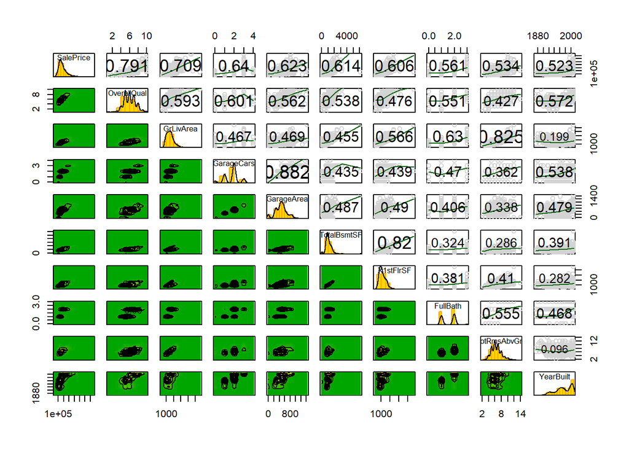

```r
kdepairs(dfSelectedCols)
```

Here we can see that there is significant multicollinearity among the variables. Also, many are skewed right (meaning the distributiion is mainly to the left of the mean.)

#### 1b. Provide a scatterplot matrix for at least two of the independent variables and the dependent variable.

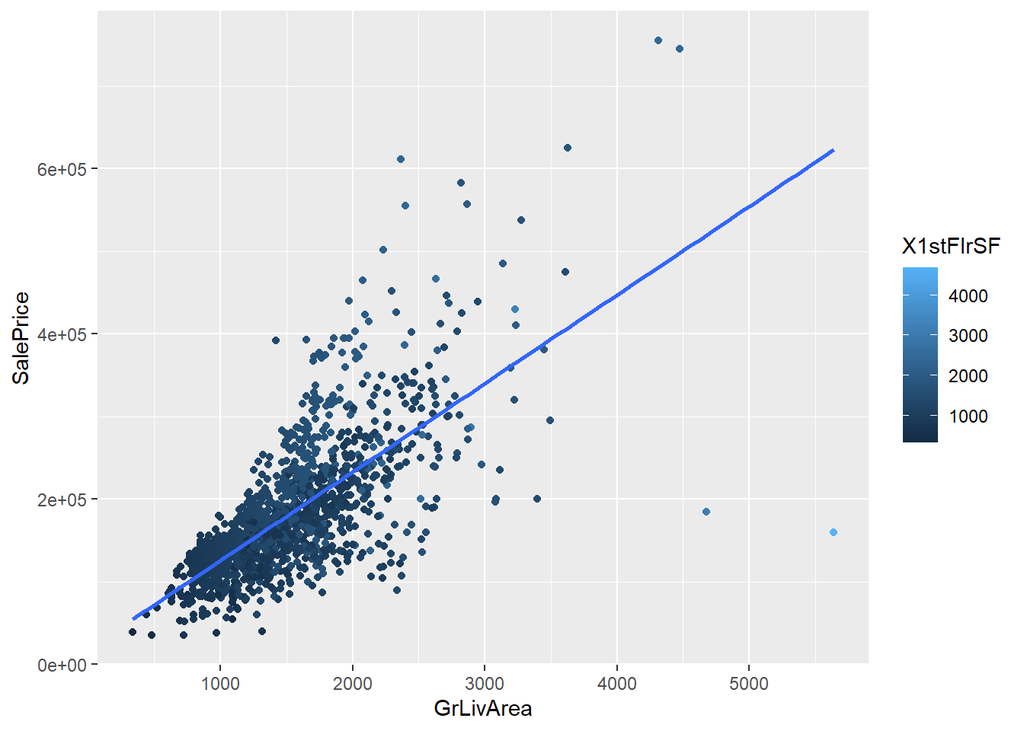

```r
ggplot(home_sales, aes(y=SalePrice, x=GrLivArea, color = X1stFlrSF)) +
  geom_point() +
    stat_smooth(method = "lm", se = FALSE)
```

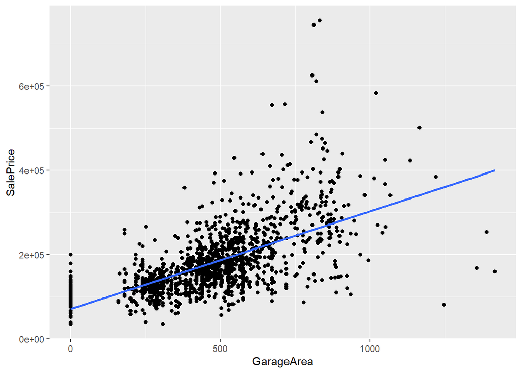

```r
ggplot(home_sales, aes(y=SalePrice, x=GarageArea)) +
  geom_point() +
    stat_smooth(method = "lm", se = FALSE)
```

Here we can see that GrLivArea, X1stFlrSF and GarageArea are all correlated with SalePrice. However, they show cone-shaped patterns which might suggest issues with heteroskedasticity, since there is more variation as values get larger.

#### 1c. Derive a correlation matrix for any three quantitative variables in the dataset. Test the hypotheses that the correlations between each pairwise set of variables is 0 and provide an 80% confidence interval. Discuss the meaning of your analysis. Would you be worried about familywise error? Why or why not? 5 point

```r
dfSelectedCols2 <- home_sales %>%
  dplyr::select(X1stFlrSF, GrLivArea, YearBuilt)

corMat <- cor(dfSelectedCols2)
corMat
```

```
##           X1stFlrSF GrLivArea YearBuilt
## X1stFlrSF 1.0000000 0.5660240 0.2819859
## GrLivArea 0.5660240 1.0000000 0.1990097
## YearBuilt 0.2819859 0.1990097 1.0000000
```

Here we see that all of the variables are correlated but particularly X1sFlrSF and GrLivArea. Looking at the p values:

```r
library(Hmisc)
res <- rcorr(as.matrix(dfSelectedCols2))
round(res$P, 3)
```

```
##           X1stFlrSF GrLivArea YearBuilt
## X1stFlrSF        NA         0         0
## GrLivArea         0        NA         0
## YearBuilt         0         0        NA
```

```r
#confidence interval X1stFlrSF vsGrLivArea
ct = cor.test(dfSelectedCols2$X1stFlrSF, dfSelectedCols2$GrLivArea, method="pearson", conf.level=.8)

ct$conf.int[1:2]
```

```
## [1] 0.5427732 0.5884078
```

```r
#confidence interval X1stFlrSF vs YearBuilt
ct = cor.test(dfSelectedCols2$X1stFlrSF,dfSelectedCols2$YearBuilt, method="pearson", conf.level=.8)

ct$conf.int[1:2]
```

```
## [1] 0.2507977 0.3125892
```

```r
#confidence interval GeLivArea vs YearBuilt
ct = cor.test(dfSelectedCols2$GrLivArea,dfSelectedCols2$YearBuilt, method="pearson", conf.level=.8)

ct$conf.int[1:2]
```

```
## [1] 0.1665605 0.2310283
```

In fact, all of the p values are 0. Confidence intervals are about +1 .03.

Family-wise error:The Family-wise error rate =
$$1 – (1-α)^n$$
where α: The significance level for a single hypothesis test n: The total number of tests

```r
alpha=.2
num=3
fwe <- 1 - (1-alpha)^num
fwe
```

```
## [1] 0.488
```

The probability of getting a type I error on at least one of the hypothesis tests is nearly 50% so I would be concerned about family-wise error.

#### 2. Invert your correlation matrix from above. (This is known as the precision matrix and contains variance inflation factors on the diagonal.) Multiply the correlation matrix by the precision matrix, and then multiply the precision matrix by the correlation matrix. Conduct LU decomposition on the matrix. 5 points

```r
precMat <- solve(corMat)
precMat
```

```
##            X1stFlrSF   GrLivArea   YearBuilt
## X1stFlrSF  1.5390352 -0.81712549 -0.27137025
## GrLivArea -0.8171255  1.47507747 -0.06313691
## YearBuilt -0.2713702 -0.06313691  1.08908743
```

Surprisingly, the VIFs are not too high.

```r
cByp <- corMat %*% precMat
pByc <- precMat %*% corMat

library(matrixcalc)
cByp_LU <- lu.decomposition(cByp)
pByc_LU <- lu.decomposition(pByc)

print(cByp_LU)
```

```
## $L
##              [,1] [,2] [,3]
## [1,] 1.000000e+00    0    0
## [2,] 1.387779e-16    1    0
## [3,] 0.000000e+00    0    1
##
## $U
##      [,1]         [,2]         [,3]
## [1,]    1 2.775558e-17 0.000000e+00
## [2,]    0 1.000000e+00 2.775558e-17
## [3,]    0 0.000000e+00 1.000000e+00
```

```r
print(pByc_LU)
```

```
## $L
##              [,1] [,2] [,3]
## [1,] 1.000000e+00    0    0
## [2,] 2.775558e-17    1    0
## [3,] 0.000000e+00    0    1
##
## $U
##      [,1]         [,2]          [,3]
## [1,]    1 1.457168e-16  5.551115e-17
## [2,]    0 1.000000e+00 -1.540744e-33
## [3,]    0 0.000000e+00  1.000000e+00
```

#### 3a. Select a variable in the Kaggle.com training dataset that is skewed to the right, shift it so that the minimum value is absolutely above zero if necessary. Then load the MASS package and run fitdistr to fit an exponential probability density function.

I will be using SalePrice, which we know is skewed from the analysis at the beginning of the exercise.

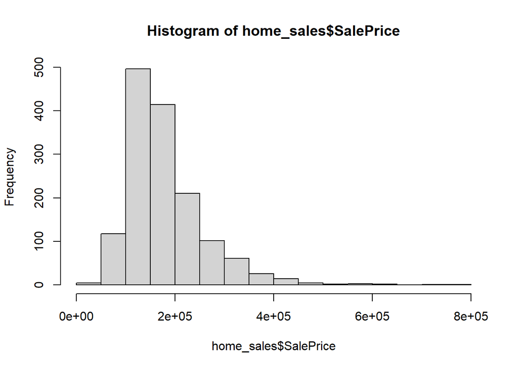

```r
hist(home_sales$SalePrice)
```

#### 3.b Find the optimal value of λ for this distribution, and then take 1000 samples from this exponential distribution using this value (e.g., rexp(1000, λ)).

We fit an exponential pdf, find the optimal lamda, and take 1000 samples.

```r
library(MASS)
fit1 <- fitdistr(home_sales$SalePrice, "exponential")
fit1
```

```
##        rate
##   5.527268e-06
##  (1.446552e-07)
```

```r
set.seed(1)
simdata = rexp(n = 1000, rate = fit1$estimate )
matrixdata =  matrix(simdata, nrow = 1000)
means.exp = apply(matrixdata, 1, mean)
```

#### 3.c Plot a histogram and compare it with a histogram of your original variable. Using the exponential pdf, find the 5th and 95th percentiles using the cumulative distribution function (CDF). Also generate a 95% confidence interval from the empirical data, assuming normality. Finally, provide the empirical 5th percentile and 95th percentile of the data. Discuss. 10 points

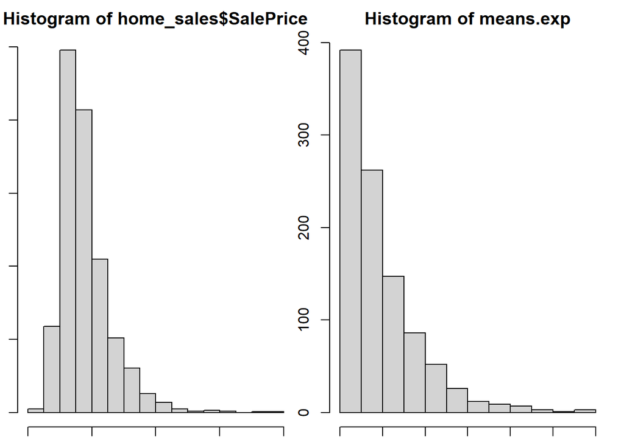

```r
par(mfcol=c(1,2), mar=c(1,1,2,1))

hist(home_sales$SalePrice)
hist(means.exp)
```

Quantiles for the generated distribution

```r
lambda <- 5.527268e-06
prob <- 0.05
# compute the quantile for Exponential dist
qexp(prob,rate=lambda)
```

```
## [1] 9280.045
```

```r
prob <- 0.95
# compute the quantile for Exponential dist
qexp(prob,rate=lambda)
```

```
## [1] 541991.5
```

Confidence interval for the mean of the empirical distribution, assuming normality

```r
t.test(home_sales$SalePrice)
```

```
##
##  One Sample t-test
##
## data:  home_sales$SalePrice
## t = 87.019, df = 1459, p-value < 2.2e-16
## alternative hypothesis: true mean is not equal to 0
## 95 percent confidence interval:
##  176842.8 184999.6
## sample estimates:
## mean of x
##  180921.2
```

Quantiles for the empirical distribution

```r
quantile(home_sales$SalePrice, probs = c(0.05, 0.95))
```

```
##     5%    95%
##  88000 326100
```

PART II Kaggle

Modeling. Build some type of multiple regression model and submit your model to the competition board. Provide your complete model summary and results with analysis. Report your Kaggle.com user name and score. 10 points

#### Data Wrangling

If we were to follow best practices, we would 1) do more investigation of the clear mulitcollinearity in the database, 2) work with all of the variables until we found the best fit, 3) find the optimal strategy for working with NAs, and 3) transform independent variables where necessary.

1. Get rid of columns that have na

We would normally investigate whether valuable data would be lost with this step - however, we can see from the above that most variables are preserved and in the interests of time will proceed.

```r
home_sales2 <- home_sales %>%
  dplyr::select_if(~ !any(is.na(.)))
```

```r
home_sales3 <- home_sales2 %>%
  dplyr::select(-Utilities) %>%
  dplyr::select(-Id)
```

3. Scale the numeric variables.

```r
numeric_data <- home_sales3 %>% select_if(is.numeric)
nonnumeric_data <- home_sales3 %>% select_if(Negate(is.numeric))

df.scaled <- as.data.frame(scale(numeric_data))
df.scaled$SalePrice <- numeric_data$SalePrice
```

4. Eliminate unbalanced character variables and then one-hot

```r
nonnumeric_data2 <- nonnumeric_data %>%
  dplyr::select(ExterQual, Exterior1st, HouseStyle, Neighborhood, LotConfig, LotShape, KitchenQual, HeatingQC, Foundation)

nonnumeric_data3 <- one_hot(as.data.table(nonnumeric_data2), dropCols=TRUE)

home_sales4 <- cbind(nonnumeric_data3, df.scaled)
```

4. Take the log of SalePrice - based on the analysis above, the analysis would benefit from this

```r
home_sales_wrangled <- home_sales4 %>%
  mutate(SalePrice = log(SalePrice))
```

#### Choosing variables for a base model

We don’t want to choose all of the variables as this would inevitably lead to multicollinearity, reduction in adjusted R squared and serious overfitting.

```r
head(dfCorr, 20)
```

```
##       Variables        V1
## 1     SalePrice 1.0000000
## 2   OverallQual 0.7909816
## 3     GrLivArea 0.7086245
## 4    GarageCars 0.6404092
## 5    GarageArea 0.6234314
## 6   TotalBsmtSF 0.6135806
## 7     X1stFlrSF 0.6058522
## 8      FullBath 0.5606638
## 9  TotRmsAbvGrd 0.5337232
## 10    YearBuilt 0.5228973
## 11 YearRemodAdd 0.5071010
## 12   Fireplaces 0.4669288
## 13   BsmtFinSF1 0.3864198
## 14   WoodDeckSF 0.3244134
## 15    X2ndFlrSF 0.3193338
## 16  OpenPorchSF 0.3158562
## 17     HalfBath 0.2841077
## 18      LotArea 0.2638434
## 19 BsmtFullBath 0.2271222
## 20    BsmtUnfSF 0.2144791
```

Based on this analysis, we’ll start with the following numeric variables and then add some categorical variable. We choose based on correlation with some attention to avoiding collineararity with other obvious variables (e.g. garage area and garage cars):

```r
mod_1 <- lm(SalePrice ~ LotArea + YearBuilt + YearRemodAdd + TotalBsmtSF + X1stFlrSF + GrLivArea + GarageCars + WoodDeckSF + OpenPorchSF + TotRmsAbvGrd + Fireplaces + FullBath, data = home_sales_wrangled)
summary(mod_1)
```

```
##
## Call:
## lm(formula = SalePrice ~ LotArea + YearBuilt + YearRemodAdd +
##     TotalBsmtSF + X1stFlrSF + GrLivArea + GarageCars + WoodDeckSF +
##     OpenPorchSF + TotRmsAbvGrd + Fireplaces + FullBath, data = home_sales_wrangled)
##
## Residuals:
##      Min       1Q   Median       3Q      Max
## -2.39969 -0.08067  0.00942  0.10116  0.58890
##
## Coefficients:
##                Estimate Std. Error  t value Pr(>|t|)
## (Intercept)   1.202e+01  4.672e-03 2573.872  < 2e-16 ***
## LotArea       1.637e-02  5.044e-03    3.246 0.001197 **
## YearBuilt     8.111e-02  7.014e-03   11.564  < 2e-16 ***
## YearRemodAdd  7.420e-02  6.059e-03   12.247  < 2e-16 ***
## TotalBsmtSF   7.132e-02  8.689e-03    8.208 4.93e-16 ***
## X1stFlrSF    -8.353e-03  9.015e-03   -0.927 0.354333
## GrLivArea     1.316e-01  1.048e-02   12.561  < 2e-16 ***
## GarageCars    7.915e-02  6.281e-03   12.601  < 2e-16 ***
## WoodDeckSF    1.850e-02  4.990e-03    3.708 0.000217 ***
## OpenPorchSF   5.140e-03  5.060e-03    1.016 0.309869
## TotRmsAbvGrd  1.122e-02  8.565e-03    1.310 0.190371
## Fireplaces    5.716e-02  5.509e-03   10.376  < 2e-16 ***
## FullBath      1.956e-05  6.949e-03    0.003 0.997755
## ---
## Signif. codes:  0 '***' 0.001 '**' 0.01 '*' 0.05 '.' 0.1 ' ' 1
##
## Residual standard error: 0.1785 on 1447 degrees of freedom
## Multiple R-squared:  0.802,  Adjusted R-squared:  0.8003
## F-statistic: 488.3 on 12 and 1447 DF,  p-value: < 2.2e-16
```

We do the same analysis with categorical variables.

```r
nonnumeric_data4 <- cbind(nonnumeric_data3, df.scaled$SalePrice)

dfCorr_cat <- as.data.frame(cor(nonnumeric_data4, nonnumeric_data4$V2)) %>%
  tibble::rownames_to_column("Variables") %>%
  arrange(desc(abs(V1)))
head(dfCorr_cat, 20)
```

```
##               Variables         V1
## 1                    V2  1.0000000
## 2          ExterQual_TA -0.5890435
## 3        KitchenQual_TA -0.5192979
## 4        KitchenQual_Ex  0.5040937
## 5      Foundation_PConc  0.4977338
## 6          ExterQual_Gd  0.4524661
## 7          ExterQual_Ex  0.4511643
## 8          HeatingQC_Ex  0.4345432
## 9  Neighborhood_NridgHt  0.4021486
## 10    Foundation_CBlock -0.3432630
## 11 Neighborhood_NoRidge  0.3304236
## 12       KitchenQual_Gd  0.3216411
## 13         HeatingQC_TA -0.3126770
## 14  Exterior1st_VinylSd  0.3050088
## 15         LotShape_Reg -0.2676718
## 16    HouseStyle_2Story  0.2428800
## 17         LotShape_IR1  0.2232839
## 18 Neighborhood_StoneBr  0.2153627
## 19    Foundation_BrkTil -0.2041174
## 20 Neighborhood_OldTown -0.1921888
```

Our New model

```r
home_sales_wrangled_Final <- home_sales_wrangled %>%
  dplyr::select(SalePrice, LotArea, YearBuilt, YearRemodAdd, TotalBsmtSF, X1stFlrSF, GrLivArea, GarageCars, WoodDeckSF, OpenPorchSF, TotRmsAbvGrd, Fireplaces, FullBath, -LotConfig_Corner:LotConfig_Inside, LotShape_IR1:LotShape_Reg)
mod_2 <- lm(SalePrice ~ ., data = home_sales_wrangled_Final)
summary(mod_2)
```

```
##
## Call:
## lm(formula = SalePrice ~ ., data = home_sales_wrangled_Final)
##
## Residuals:
##      Min       1Q   Median       3Q      Max
## -1.68788 -0.07067  0.00754  0.08927  0.45266
##
## Coefficients: (6 not defined because of singularities)
##                        Estimate Std. Error t value Pr(>|t|)
## (Intercept)           12.201201   0.060849 200.517  < 2e-16 ***
## LotArea                0.016596   0.005098   3.255 0.001159 **
## YearBuilt              0.052924   0.010535   5.024 5.72e-07 ***
## YearRemodAdd           0.058234   0.005915   9.845  < 2e-16 ***
## TotalBsmtSF            0.062413   0.008179   7.631 4.30e-14 ***
## X1stFlrSF             -0.040420   0.014081  -2.871 0.004159 **
## GrLivArea              0.138632   0.015661   8.852  < 2e-16 ***
## GarageCars             0.060758   0.005830  10.421  < 2e-16 ***
## WoodDeckSF             0.021413   0.004499   4.760 2.14e-06 ***
## OpenPorchSF            0.006232   0.004652   1.340 0.180528
## TotRmsAbvGrd           0.015116   0.007873   1.920 0.055076 .
## Fireplaces             0.042155   0.005206   8.098 1.21e-15 ***
## FullBath              -0.001961   0.006531  -0.300 0.763965
## ExterQual_Ex           0.121933   0.029899   4.078 4.80e-05 ***
## ExterQual_Fa          -0.245671   0.046068  -5.333 1.13e-07 ***
## ExterQual_Gd           0.034928   0.014249   2.451 0.014358 *
## ExterQual_TA                 NA         NA      NA       NA
## Exterior1st_AsbShng   -0.084483   0.047533  -1.777 0.075727 .
## Exterior1st_AsphShn    0.031127   0.161970   0.192 0.847631
## Exterior1st_BrkComm   -0.372751   0.115593  -3.225 0.001290 **
## Exterior1st_BrkFace    0.096450   0.038671   2.494 0.012743 *
## Exterior1st_CBlock     0.269128   0.166447   1.617 0.106127
## Exterior1st_CemntBd    0.054094   0.041078   1.317 0.188106
## Exterior1st_HdBoard    0.003150   0.033765   0.093 0.925689
## Exterior1st_ImStucc    0.062485   0.161799   0.386 0.699415
## Exterior1st_MetalSd    0.011538   0.032943   0.350 0.726206
## Exterior1st_Plywood   -0.005964   0.035672  -0.167 0.867236
## Exterior1st_Stone      0.124093   0.118159   1.050 0.293799
## Exterior1st_Stucco    -0.023784   0.044905  -0.530 0.596439
## Exterior1st_VinylSd    0.013061   0.033191   0.394 0.694001
```

[output cut: 35 more lines]

```
## LotConfig_Corner      -0.001265   0.011091  -0.114 0.909221
## LotConfig_CulDSac      0.042573   0.018674   2.280 0.022770 *
## LotConfig_FR2         -0.050026   0.023992  -2.085 0.037244 *
## LotConfig_FR3         -0.033854   0.078985  -0.429 0.668270
## LotConfig_Inside             NA         NA      NA       NA
## LotShape_IR1           0.003674   0.010167   0.361 0.717905
## LotShape_IR2           0.031639   0.027288   1.159 0.246477
## LotShape_IR3          -0.209407   0.053200  -3.936 8.68e-05 ***
## LotShape_Reg                 NA         NA      NA       NA
## ---
## Signif. codes:  0 '***' 0.001 '**' 0.01 '*' 0.05 '.' 0.1 ' ' 1
##
## Residual standard error: 0.1555 on 1392 degrees of freedom
## Multiple R-squared:  0.8555, Adjusted R-squared:  0.8486
## F-statistic:   123 on 67 and 1392 DF,  p-value: < 2.2e-16
```

We now step through the model to see the effect on adjusted R squared of eliminating variables. We do this with the R Step_AIC function.

```r
library(MASS)
step1 <- stepAIC(mod_2, trace=FALSE)
summary(step1)
```

```
##
## Call:
## lm(formula = SalePrice ~ LotArea + YearBuilt + YearRemodAdd +
##     TotalBsmtSF + X1stFlrSF + GrLivArea + GarageCars + WoodDeckSF +
##     OpenPorchSF + TotRmsAbvGrd + Fireplaces + ExterQual_Ex +
##     ExterQual_Fa + ExterQual_Gd + Exterior1st_AsbShng + Exterior1st_BrkComm +
##     Exterior1st_BrkFace + Exterior1st_CBlock + Exterior1st_CemntBd +
##     HouseStyle_1.5Fin + HouseStyle_1Story + HouseStyle_2Story +
##     Neighborhood_Blmngtn + Neighborhood_Blueste + Neighborhood_BrDale +
##     Neighborhood_BrkSide + Neighborhood_ClearCr + Neighborhood_CollgCr +
##     Neighborhood_Edwards + Neighborhood_Gilbert + Neighborhood_IDOTRR +
##     Neighborhood_MeadowV + Neighborhood_Mitchel + Neighborhood_NAmes +
##     Neighborhood_NPkVill + Neighborhood_NWAmes + Neighborhood_OldTown +
##     Neighborhood_Sawyer + Neighborhood_SawyerW + Neighborhood_Somerst +
##     Neighborhood_StoneBr + Neighborhood_SWISU + Neighborhood_Timber +
##     LotConfig_CulDSac + LotConfig_FR2 + LotShape_IR3, data = home_sales_wrangled_Final)
##
## Residuals:
##      Min       1Q   Median       3Q      Max
## -1.70678 -0.06919  0.00698  0.08967  0.44429
##
## Coefficients:
##                       Estimate Std. Error t value Pr(>|t|)
## (Intercept)          12.210131   0.020784 587.491  < 2e-16 ***
## LotArea               0.017177   0.004950   3.470 0.000536 ***
## YearBuilt             0.055347   0.008780   6.304 3.87e-10 ***
## YearRemodAdd          0.059384   0.005746  10.335  < 2e-16 ***
## TotalBsmtSF           0.060680   0.007801   7.779 1.40e-14 ***
## X1stFlrSF            -0.034522   0.012356  -2.794 0.005277 **
## GrLivArea             0.130573   0.013179   9.908  < 2e-16 ***
## GarageCars            0.060718   0.005740  10.579  < 2e-16 ***
## WoodDeckSF            0.020869   0.004412   4.730 2.47e-06 ***
## OpenPorchSF           0.006721   0.004564   1.473 0.141101
## TotRmsAbvGrd          0.015397   0.007580   2.031 0.042417 *
## Fireplaces            0.041652   0.005057   8.237 3.98e-16 ***
## ExterQual_Ex          0.129186   0.028414   4.547 5.92e-06 ***
## ExterQual_Fa         -0.240883   0.045471  -5.298 1.36e-07 ***
## ExterQual_Gd          0.035159   0.013863   2.536 0.011312 *
## Exterior1st_AsbShng  -0.089004   0.035832  -2.484 0.013110 *
## Exterior1st_BrkComm  -0.378983   0.111112  -3.411 0.000666 ***
```

[output cut: 21 more lines]

```
## Neighborhood_Sawyer  -0.209401   0.024155  -8.669  < 2e-16 ***
## Neighborhood_SawyerW -0.160759   0.024413  -6.585 6.40e-11 ***
## Neighborhood_Somerst -0.076205   0.022551  -3.379 0.000747 ***
## Neighborhood_StoneBr  0.059844   0.034087   1.756 0.079368 .
## Neighborhood_SWISU   -0.191249   0.037018  -5.166 2.73e-07 ***
## Neighborhood_Timber  -0.079425   0.028857  -2.752 0.005993 **
## LotConfig_CulDSac     0.045693   0.017207   2.655 0.008010 **
## LotConfig_FR2        -0.048623   0.023339  -2.083 0.037396 *
## LotShape_IR3         -0.216193   0.052148  -4.146 3.59e-05 ***
## ---
## Signif. codes:  0 '***' 0.001 '**' 0.01 '*' 0.05 '.' 0.1 ' ' 1
##
## Residual standard error: 0.1547 on 1413 degrees of freedom
## Multiple R-squared:  0.8548, Adjusted R-squared:  0.8501
## F-statistic: 180.8 on 46 and 1413 DF,  p-value: < 2.2e-16
```

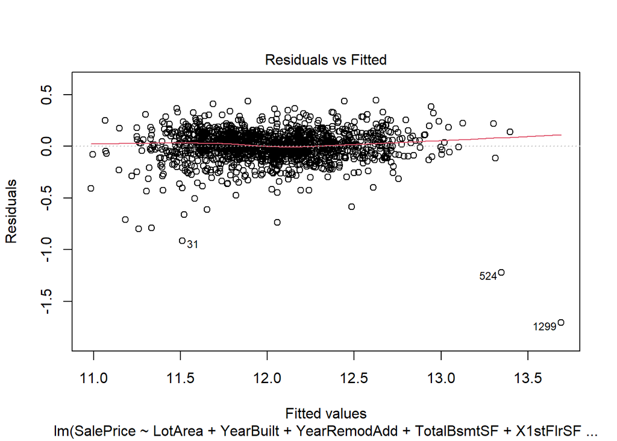

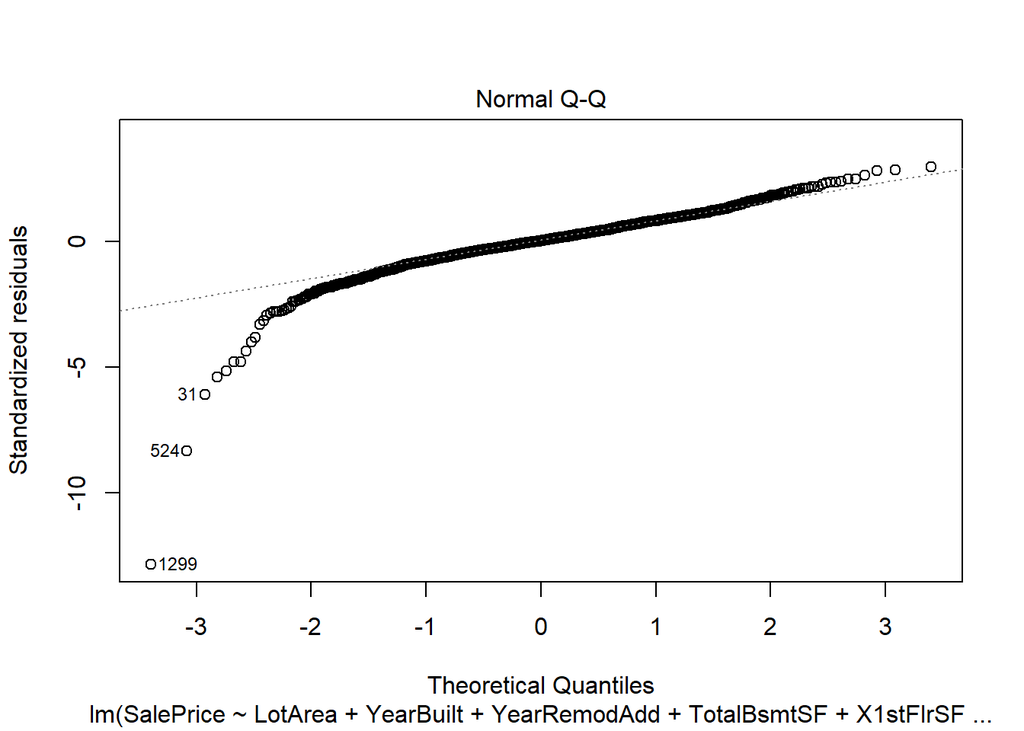

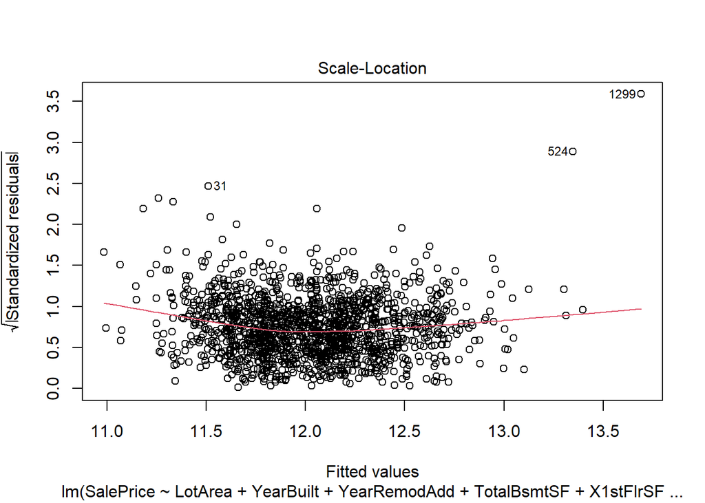

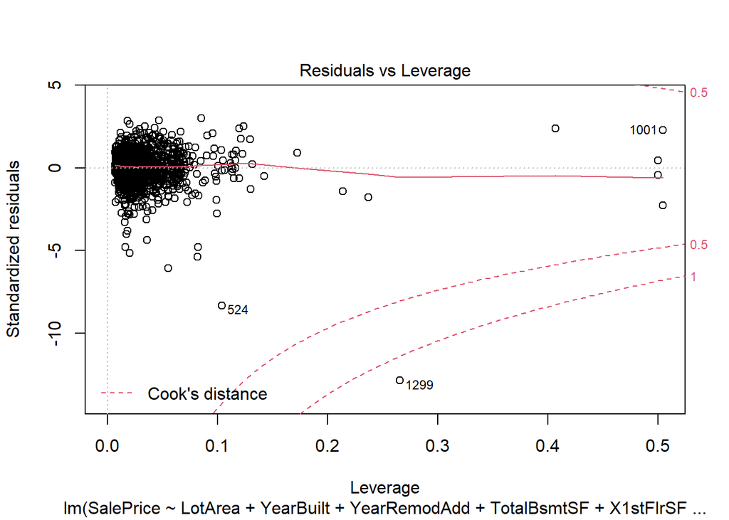

```r
plot(step1)
```

Thus our new df:

```r
dfFinal <- step1$model
head(dfFinal)
```

```
##   SalePrice     LotArea  YearBuilt YearRemodAdd TotalBsmtSF   X1stFlrSF
## 1  12.24769 -0.20707076  1.0506338    0.8783671  -0.4591452 -0.79316202
## 2  12.10901 -0.09185490  0.1566800   -0.4294298   0.4663051  0.25705235
## 3  12.31717  0.07345481  0.9844150    0.8299302  -0.3132614 -0.62761099
## 4  11.84940 -0.09686428 -1.8629933   -0.7200514  -0.6870887 -0.52155486
## 5  12.42922  0.37501979  0.9513056    0.7330564   0.1996113 -0.04559563
## 6  11.87060  0.36049258  0.7195398    0.4908717  -0.5959113 -0.94836612
##    GrLivArea GarageCars WoodDeckSF OpenPorchSF TotRmsAbvGrd Fireplaces
## 1  0.3702066  0.3116179 -0.7519182  0.21642900    0.9118973 -0.9509007
## 2 -0.4823466  0.3116179  1.6256378 -0.70424195   -0.3185741  0.6002892
## 3  0.5148362  0.3116179 -0.7519182 -0.07033736   -0.3185741  0.6002892
## 4  0.3835277  1.6497417 -0.7519182 -0.17598812    0.2966616  0.6002892
## 5  1.2988806  1.6497417  0.7799299  0.56356723    1.5271330  0.6002892
## 6 -0.2920446  0.3116179 -0.4327832 -0.25145296   -0.9338098 -0.9509007
##   ExterQual_Ex ExterQual_Fa ExterQual_Gd Exterior1st_AsbShng
```

[output cut: 76 more lines]

We Load test data and prepare as we did the training data

```r
numeric_data_test <- home_kaggle_test %>% select_if(is.numeric)
nonnumeric_data_test <- home_kaggle_test %>% select_if(Negate(is.numeric))

#1. one-hot the categorical variables

nonnumeric_data_test1 <- nonnumeric_data_test %>%
  dplyr::select(ExterQual, Exterior1st, HouseStyle, Neighborhood, KitchenQual, HeatingQC, Foundation)

nonnumeric_data_OneHot <- one_hot(as.data.table(nonnumeric_data_test1), dropCols=TRUE)

#Scale the numeric variables

df.scaled_test <- as.data.frame(scale(numeric_data_test))
df.scaled_test$Id <- numeric_data_test$Id

#recombine

dfTest_Final <- cbind(df.scaled_test, nonnumeric_data_OneHot)
```

We Check if the dataset is missing columns from the test dataset and if, so drop them from the original

```r
library(janitor)
compare_df_cols(dfTest_Final, dfFinal)
```

```
##              column_name dfTest_Final dfFinal
## 1           BedroomAbvGr      numeric    <NA>
## 2             BsmtFinSF1      numeric    <NA>
## 3             BsmtFinSF2      numeric    <NA>
## 4           BsmtFullBath      numeric    <NA>
## 5           BsmtHalfBath      numeric    <NA>
## 6              BsmtUnfSF      numeric    <NA>
## 7          EnclosedPorch      numeric    <NA>
## 8    Exterior1st_AsbShng      integer integer
## 9    Exterior1st_AsphShn      integer    <NA>
## 10   Exterior1st_BrkComm      integer integer
## 11   Exterior1st_BrkFace      integer integer
## 12    Exterior1st_CBlock      integer integer
## 13   Exterior1st_CemntBd      integer integer
## 14   Exterior1st_HdBoard      integer    <NA>
```

[output cut: 91 more lines]

```r
dfFinal1 <- dfFinal %>%
  dplyr::select(-LotConfig_CulDSac) %>%
  dplyr::select(-LotConfig_FR2)  %>%
  dplyr::select(-LotShape_IR3)
```

We Run the model

```r
mod_3 <- lm(SalePrice ~ ., data = dfFinal1)
step2 <- stepAIC(mod_3, trace=FALSE)
summary(step2)
```

```
##
## Call:
## lm(formula = SalePrice ~ LotArea + YearBuilt + YearRemodAdd +
##     TotalBsmtSF + X1stFlrSF + GrLivArea + GarageCars + WoodDeckSF +
##     OpenPorchSF + TotRmsAbvGrd + Fireplaces + ExterQual_Ex +
##     ExterQual_Fa + ExterQual_Gd + Exterior1st_AsbShng + Exterior1st_BrkComm +
##     Exterior1st_BrkFace + Exterior1st_CBlock + Exterior1st_CemntBd +
##     HouseStyle_1.5Fin + HouseStyle_1Story + HouseStyle_2Story +
##     Neighborhood_Blmngtn + Neighborhood_Blueste + Neighborhood_BrDale +
##     Neighborhood_BrkSide + Neighborhood_ClearCr + Neighborhood_CollgCr +
##     Neighborhood_Edwards + Neighborhood_Gilbert + Neighborhood_IDOTRR +
##     Neighborhood_MeadowV + Neighborhood_Mitchel + Neighborhood_NAmes +
##     Neighborhood_NPkVill + Neighborhood_NWAmes + Neighborhood_OldTown +
##     Neighborhood_Sawyer + Neighborhood_SawyerW + Neighborhood_Somerst +
##     Neighborhood_StoneBr + Neighborhood_SWISU + Neighborhood_Timber,
##     data = dfFinal1)
##
## Residuals:
##      Min       1Q   Median       3Q      Max
## -1.88190 -0.06774  0.00570  0.09016  0.45200
##
## Coefficients:
##                       Estimate Std. Error t value Pr(>|t|)
## (Intercept)          12.213769   0.020797 587.292  < 2e-16 ***
## LotArea               0.013571   0.004791   2.832 0.004685 **
## YearBuilt             0.054391   0.008852   6.144 1.04e-09 ***
## YearRemodAdd          0.059118   0.005795  10.201  < 2e-16 ***
## TotalBsmtSF           0.057700   0.007840   7.360 3.12e-13 ***
## X1stFlrSF            -0.031653   0.012455  -2.541 0.011146 *
## GrLivArea             0.128515   0.013291   9.669  < 2e-16 ***
## GarageCars            0.061541   0.005788  10.632  < 2e-16 ***
## WoodDeckSF            0.021887   0.004446   4.923 9.55e-07 ***
## OpenPorchSF           0.006798   0.004600   1.478 0.139674
## TotRmsAbvGrd          0.015724   0.007640   2.058 0.039764 *
## Fireplaces            0.042165   0.005099   8.269 3.07e-16 ***
## ExterQual_Ex          0.128777   0.028674   4.491 7.66e-06 ***
## ExterQual_Fa         -0.239340   0.045886  -5.216 2.10e-07 ***
## ExterQual_Gd          0.035292   0.013989   2.523 0.011751 *
## Exterior1st_AsbShng  -0.088973   0.036159  -2.461 0.013988 *
## Exterior1st_BrkComm  -0.379176   0.112127  -3.382 0.000740 ***
```

[output cut: 18 more lines]

```
## Neighborhood_NPkVill -0.214338   0.054710  -3.918 9.37e-05 ***
## Neighborhood_NWAmes  -0.150322   0.023255  -6.464 1.40e-10 ***
## Neighborhood_OldTown -0.267340   0.025049 -10.673  < 2e-16 ***
## Neighborhood_Sawyer  -0.208357   0.024308  -8.572  < 2e-16 ***
## Neighborhood_SawyerW -0.163728   0.024521  -6.677 3.49e-11 ***
## Neighborhood_Somerst -0.077411   0.022738  -3.405 0.000681 ***
## Neighborhood_StoneBr  0.070917   0.034226   2.072 0.038441 *
## Neighborhood_SWISU   -0.195840   0.037291  -5.252 1.74e-07 ***
## Neighborhood_Timber  -0.078573   0.029061  -2.704 0.006939 **
## ---
## Signif. codes:  0 '***' 0.001 '**' 0.01 '*' 0.05 '.' 0.1 ' ' 1
##
## Residual standard error: 0.1561 on 1416 degrees of freedom
## Multiple R-squared:  0.8518, Adjusted R-squared:  0.8473
## F-statistic: 189.3 on 43 and 1416 DF,  p-value: < 2.2e-16
```

We examine the residual plots.

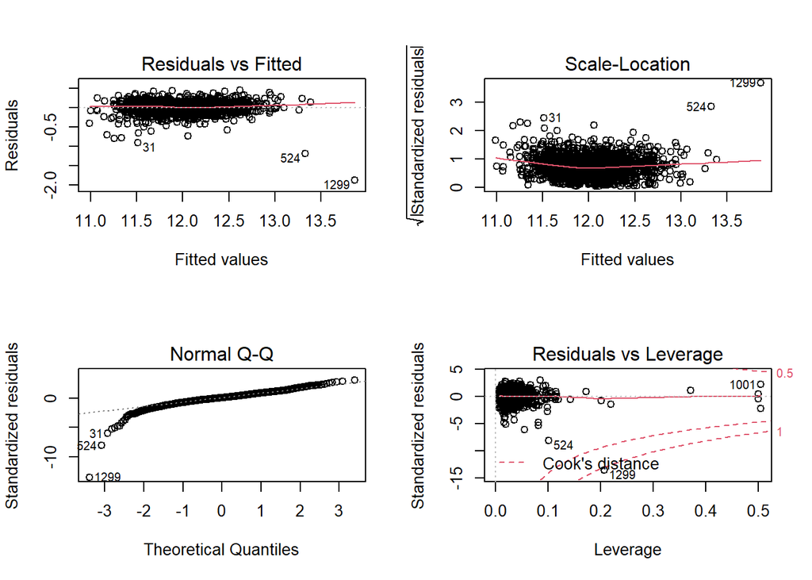

```r
par(mfcol=c(2,2))
plot(step2)
```

The residuals are relatively normally-distributed, though there are some outliers. Heteroskedasticity is present but minimal.

Now we make predictions

```r
makePredictions <- function(df)
{
predictions <- predict(df,newdata=dfTest_Final)
predictions <- data.frame(as.vector(predictions))
predictions$Id <- dfTest_Final$Id
predictions[,c(1,2)] <- predictions[,c(2,1)]
colnames(predictions) <- c("Id", "SalePrice")
predictions[is.na(predictions)] <- log(mean(home_sales$SalePrice))
predictions$SalePrice <- exp(predictions$SalePrice)
write_csv(predictions, "C:\\Users\\Eric\\Desktop\\predictions.csv")
}

makePredictions(step2)
```

Remove outliers

```r
dfFinal2 <- slice(dfFinal1, -1299)
dfFinal2 <- slice(dfFinal2, -524)
dfFinal2 <- slice(dfFinal2, -1001)
```

```r
mod_4 <- lm(SalePrice ~ ., data = dfFinal2)
step3 <- stepAIC(mod_4, trace=FALSE)
print(summary(step3)$adj.r.squared)
```

```
## [1] 0.8770031
```

We remove outliers and the R squared improves.We submit this new model:

```r
makePredictions(step3)
```

Therefore we stick with our first model.

[figure not shown]